# ooo

### beyond pipelining: multiple issue

- start *more than one instruction/cycle*
- multiple parallel pipelines; many-input/output register file
- *hazard handling much more complex*

[figure not shown]

### beyond pipelining: out-of-order

- find *later instructions to do* instead of stalling
- lists of available instructions in pipeline registers
  - take any instruction with available values
- provide *illusion that work is still done in order*
  - much more complicated hazard handling logic

[figure not shown]

### interlude: real CPUs

- modern CPUs:
- execute *multiple instructions at once*
- execute instructions *out of order* — whenever *values available*

### out-of-order and hazards

- out-of-order execution makes hazards harder to handle
- problems for forwarding:
  - value in last stage may not be most up-to-date
  - older value may be written back before newer value?
- problems for branch prediction:
  - mispredicted instructions may complete execution before squashing
- which instructions to dispatch?
  - how to quickly find instructions that are ready?

### read-after-write examples (1)

[figure not shown]

normal pipeline: two options for %r8?  
choose the one from *earliest stage*  
because it’s from the most recent instruction

[figure not shown]

out-of-order execution:  
`%r8` from earliest stage might be from delayed instruction  
can’t use same forwarding logic

### register version tracking

- goal: track *different versions of registers*
- out-of-order execution: may compute versions at different times
- only forward the *correct version*
- strategy for doing this: preprocess instructions represent version info
- makes forwarding, etc. lookup easier

### rewriting hazard examples (1)

| `addq %r10, %r8` | `addq %r10v1, %r8v1 \(\rightarrow\) %r8v2` |
| --- | --- |
| `addq %r11, %r8` | `addq %r11v1, %r8v2 \(\rightarrow\) %r8v3` |
| `addq %r12, %r8` | `addq %r12v1, %r8v3 \(\rightarrow\) %r8v4` |

- read different version than the one written
  - represent with three argument psuedo-instructions
- forwarding a value? must match version *exactly*
- for now: version numbers
- later: something simpler to implement

### write-after-write example

[figure not shown]

many instructions producing differnt version of `%r8`  
most recently run instruction may be writing *outdated version*

multiple instructions that haven’t started  
could need *different versions* of `%r8`

### keeping multiple versions

- for write-after-write problem: need to keep copies of multiple versions
  - both the new version and the old version needed by delayed instructions
- for read-after-write problem: need to distinguish different versions
- solution: *have lots of extra registers*
- *… and assign each version a new ‘real’ register*
- called *register renaming*

### register renaming

- rename *architectural registers* to *physical registers*
- different physical register for each version of architectural
- track which physical registers are ready
- compare physical register numbers to do forwarding

### an OOO pipeline

[figure not shown]

### an OOO pipeline (branch prediction)

[figure not shown]

branch prediction needs to happen before instructions decoded  
done with cache-like tables of information about recent branches

### an OOO pipeline (register renaming)

[figure not shown]

register renaming after decoding  
where mapping from architectural to physical names kept

“dispatch” instructions = add to instruction queue  
also requires preparing reorder buffer (for handling squashing)

### an OOO pipeline (instruction queue)

[figure not shown]

instruction queue holds pending renamed instructions  
combined with register-ready info to *issue* instructions  
(*issue* = start executing)

### an OOO pipeline (starting instruction)

[figure not shown]

after selecting from instruction queue,  
read from large register file and handle forwarding

typically read 6+ registers at a time  
extra data paths for forwarding (not drawn)

### an OOO pipeline (execution units)

[figure not shown]

many *execution units* actually do math or cache load/store  
some may have multiple pipeline stages  
some may take variable time (data cache, integer divide, …)

### an OOO pipeline (writeback)

[figure not shown]

writeback to physical registers  
register file typically supports writing 3+ registers at a time

### an OOO pipeline (commit)

[figure not shown]

new commit (sometimes *retire*) stage finalized instruction  
figures out when physical registers can be reused

also tracks bookkeeping information if we need to undo instruction  
(because of branch misprediction/segfault/etc.)

### an OOO pipeline diagram

[figure not shown]

### an OOO pipeline (register renaming)

[figure not shown]

### register renaming

- rename *architectural registers* to *physical registers*
  - architectural = part of instruction set architecture
- different name for each version of architectural register

### register renaming state

[figure not shown]

### register renaming example (1)

[figure not shown]

### register renaming example (2)

[figure not shown]

### register renaming exercise

[figure not shown]

### an OOO pipeline (starting instruction)

[figure not shown]

### instruction queue and dispatch

[figure not shown]

### instruction queue and dispatch ex

[figure not shown]

### an OOO pipeline (execution units)

[figure not shown]

### execution units AKA functional units (1a)

- where actual work of instruction is done
- e.g. the actual ALU, or data cache
- sometimes pipelined:
  - (here: 1 op/cycle; 3 cycle latency)

[figure not shown]

- exercise: how long to compute $A\times (B\times (C\times D))$?

$3\times 3$ cycles + any time to forward values

### execution units AKA functional units (1b)

[figure not shown]

- exercise: how long to compute $(A\times B)\times (C\times D)$?

assuming just one ALU:

|  | 1 | 2 | 3 | 4 | 5 | 6 | 7 |
| --- | --- | --- | --- | --- | --- | --- | --- |
| $A\times B$ | 1 | 2 | 3 |  |  |  |  |
| $C\times D$ |  | 1 | 2 | 3 |  |  |  |
| *final* |  |  |  |  | 1 | 2 | 3 |

- exercise part 2: how much would second ALU help?

### execution units AKA functional units (2)

- where actual work of instruction is done
- e.g. the actual ALU, or data cache
- sometimes unpipelined:

[figure not shown]

### instruction queue and dispatch (multicycle)

[figure not shown]

### register renaming: missing pieces

- what about ‘‘hidden’’ inputs like `%rsp`, condition codes?
- one solution: translate to intructions with additional register parameters
  - making %rsp explicit parameter
  - turning hidden condition codes into operands!
- bonus: can also translate complex instructions to simpler ones

[figure not shown]

### data flow visualization

[figure not shown]

### OOO limitations

- can’t always find instructions to run
  - plenty of instructions, but all depend on unfinished ones
  - programmer can adjust program to help this
- need to track all uncommitted instructions
  - can only go so far ahead
  - e.g. Intel Skylake: 224-entry reorder buffer, 168 physical registers
- branch misprediction has a big cost (relative to pipelined)
  - e.g. Intel Skylake: up to approx. 16 cycles (v. 2 for simple pipelined CPU)

### some performance examples

[figure not shown]

### data flow model and limits

[figure not shown]

# Backup slides

### backup slides

### data flow model and limits (1)

[figure not shown]

### data flow visualization

[figure not shown]

### Intel Skylake OOO design

- 2015 Intel design — codename ‘Skylake’
- 94-entry instruction queue-equivalent
- 168 physical integer registers
- 168 physical floating point registers
- 4 ALU functional units
  - but some can handle more/different types of operations than others
- 2 load functional units
  - but pipelined: supports multiple pending cache misses in parallel
- 1 store functional unit
- 224-entry reorder buffer
  - determines how far ahead branch mispredictions, etc. can happen

### indirect branch prediction

- `jmp *%rax` or `jmp *(%rax, %rcx, 8)` or `call *%rax` or …
  - example: implementing switch statement
  - example: implementing polymorphic method call
- want to predict *target address*
- BTB could store one possibility
- really want to take advantage of context
  - example: guess whether we’ll call Rectangle.GetArea or Circle.GetArea
- prediction idea: instead of tables containing taken/not taken…
- … have table containing predicted target
  - one implementation: hashtable keyed by recent branches taken

### reorder buffer: on rename

[figure not shown]

### reorder buffer: on commit

[figure not shown]

### reorder buffer: commit mispredict (one way)

[figure not shown]

### better? alternatives

- can take snapshots of register map on each branch
  - don’t need to reconstruct the table
  - (but how to efficiently store them)
- can reconstruct register map before we commit the branch instruction
  - need to let reorder buffer be accessed even more?
- can track more/different information in reorder buffer

### exceptions and OOO (one strategy)

[figure not shown]

### the open-source BROOM pipeline

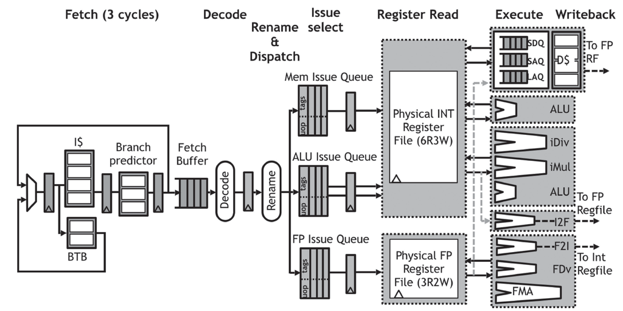

Figure from Celio et al., ‘‘BROOM: An Open Source Out-Of-Order Processor With Resilient Low-Voltage Operation in 28-nm CMOS’’

### data flow model and limits

[figure not shown]

### better data-flow

[figure not shown]

```
int sum1 = 0, sum2 = 0;
for (int i = 0; i < N; i += 2) {
    sum1 += array[i]
    sum2 += array[i+1]
}
sum = sum1 + sum2;
```

### register renaming: missing pieces

- what about ‘‘hidden’’ inputs like `%rsp`, condition codes?
- one solution: translate to intructions with additional register parameters
  - making %rsp explicit parameter
  - turning hidden condition codes into operands!
- bonus: can also translate complex instructions to simpler ones

[figure not shown]

## data flow as loop optimization

### data flow model and limits

[figure not shown]

### better data-flow

[figure not shown]

```
int sum1 = 0, sum2 = 0;
for (int i = 0; i < N; i += 2) {
    sum1 += array[i]
    sum2 += array[i+1]
}
sum = sum1 + sum2;
```